# Data Analytics INDE 6645-Term Project

Bhushan Gorule, Gurukaran Singh Kochar, Saket Surangalikar

29 April 2021

# 1. Executive summary

### Internet of things (IoT) takes multiple devices like security cameras, GPS tracking, retail POS machines, etc. and connects them to a cellular network connection. Such connected devices are considered a part of an IoT network when they communicate back and forth with a central hub. In recent years, the rise of the Internet of things (IoT) as an emerging technology has been unbelievable, more companies are moving towards the adoption of these technologies and many IoT devices are being deployed to share information in real-time which leads to the generation of a huge amount of data. This data when used correctly, will be very helpful to the company to discover hidden patterns for better decision making in the future. For example, with the DataCo company, dataset shipment analysis was performed in this project which helps the company to better understand its supply chain and target critical factors to increase customer responsiveness and the company’s revenue.

### In this project we compared 3 popular regressors type machine learning models and measured their performance to find out which machine learning model performs better. Since the dataset used is related to supply chain, important parameters are related to shipment and the machine learning models are trained with the shipment dataset.

### The machine learning models used in this project are Linear Regression, Random Forest regression, and Gradient Boosting regression to predict number of days for shipment which are compared with mean absolute error (MAE) and root mean square error (RMSE).

# 2. Problem statement

# 3. Data Preprocessing

## 3.a) Defining and collecting data.

### The dataset used in this project is maintained transparently with the Creative Commons 4.0 license by Fabian Constante, Fernando Silva, and António Pereira through the Mendeley data repository. The dataset consists of roughly 180k transactions from supply chains used by the company DataCo Global for 3 years. The dataset can be downloaded from:

### https://data.mendeley.com/datasets/8gx2fvg2k6/5

### Import data set

```r
library(dplyr)
```

```r
library(corrplot)
library(tidyverse)
library(sf)
library(maps)
library(ggplot2)
library(rpart)
library(rpart.plot)
library(data.table)
data <- read.csv("DataCoSupplyChainDataset.csv")
#head(data)
```

### EXPLORATORY DATA ANALYSIS [EDA]

```r
dim(data) # Gives number of rows(180519) and columns(53) in the data set
```

```
## [1] 180519     53
```

```r
datapoints<-ncol(data)*nrow(data) # number of datapoints in the data set
datapoints
```

```
## [1] 9567507
```

```r
numeric<-names(data[, sapply(data, is.numeric)])
length(unique(numeric)) # number of numeric columns
```

```
## [1] 28
```

```r
categorical<-names(data[, sapply(data, is.character)])
length(unique(categorical)) # number of categorical columns
```

```
## [1] 24
```

### The total data set consists of 180519 records and 53 columns. There are total 28 numeric variables and 24 categorical variables.

### Let us now check Missing data

```r
sum(is.na(data)) # total number of missing values
```

```
## [1] 336201
```

```r
null_values<-lapply(data, function(data) sum(is.na(data))) # It will return the column name along with the missing values
#null_values
null_values$Product.Description
```

```
## [1] 180519
```

```r
null_values$Customer.Zipcode
```

```
## [1] 3
```

```r
null_values$Order.Zipcode
```

```
## [1] 155679
```

```r
total_null_values<-null_values$Product.Description+null_values$Customer.Zipcode+null_values$Order.Zipcode
print(total_null_values)
```

```
## [1] 336201
```

### The data consists of some missing values from Product Description, Order Zipcode and, Customer Zipcode which should be removed or replaced before proceeding with the analysis.

## 3.b) Organizing and Visualizing Variables

## Plotting correlogram

```r
numeric_data <- select_if(data,is.numeric)
#numeric_data
categorical_data <- select_if(data,is.character)
#categorical_data
correlation <- round(cor(numeric_data),2)
```

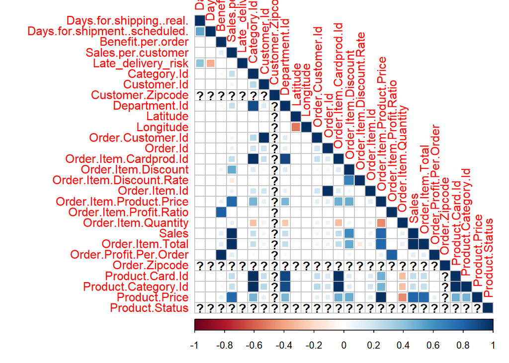

```r
#correlation
corrplot(correlation,method = "square",type = "lower")
```

### Unwanted features(null or less correlated values)

## Let us now clean the data set by removing duplicate and redundant columns.

```r
#head(data)
v_data <- data[,c(1:11,13:15,17,18,20:27,29:34,36:38,41:43,45,49,50,52,53)]
dim(v_data)
```

```
## [1] 180519     41
```

```r
#head(v_data)
```

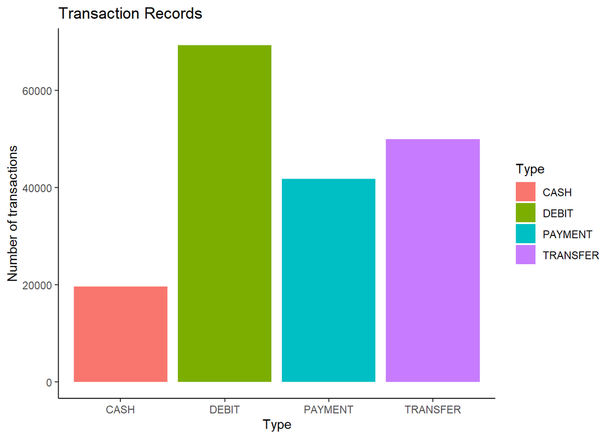

```r
bar <- ggplot(v_data ,aes(x=Type,fill=Type))
bar + geom_bar() + theme_classic() + labs(y="Number of transactions", title= "Transaction Records")
```

### The graph shows that highest number of transactions are in the form of Debit and the lowest number of transactions are in the form of cash.

```r
total_sales <- v_data%>%
   group_by(Category.Name)
total_sales
```

```
## # A tibble: 180,519 x 41
## # Groups:   Category.Name [50]
##    Type  Days.for.shippi~ Days.for.shipme~ Benefit.per.ord~ Sales.per.custo~
##    <chr>            <int>            <int>            <dbl>            <dbl>
##  1 DEBIT                3                4             91.2             315.
##  2 TRAN~                5                4           -249.              311.
##  3 CASH                 4                4           -248.              310.
##  4 DEBIT                3                4             22.9             305.
##  5 PAYM~                2                4            134.              298.
##  6 TRAN~                6                4             18.6             295.
##  7 DEBIT                2                1             95.2             288.
##  8 TRAN~                2                1             68.4             285.
##  9 CASH                 3                2            134.              279.
## 10 CASH                 2                1            132.              275.
## # ... with 180,509 more rows, and 36 more variables: Delivery.Status <chr>,
## #   Late_delivery_risk <int>, Category.Id <int>, Category.Name <chr>,
## #   Customer.City <chr>, Customer.Country <chr>, Customer.Fname <chr>,
## #   Customer.Id <int>, Customer.Lname <chr>, Customer.Segment <chr>,
## #   Customer.State <chr>, Customer.Zipcode <int>, Department.Id <int>,
## #   Department.Name <chr>, Latitude <dbl>, Longitude <dbl>, Market <chr>,
## #   Order.City <chr>, Order.Country <chr>, order.date..DateOrders. <chr>,
## #   Order.Id <int>, Order.Item.Cardprod.Id <int>, Order.Item.Discount <dbl>,
## #   Order.Item.Discount.Rate <dbl>, Order.Item.Id <int>,
## #   Order.Item.Profit.Ratio <dbl>, Order.Item.Quantity <int>, Sales <dbl>,
## #   Order.Region <chr>, Order.State <chr>, Order.Status <chr>,
## #   Product.Card.Id <int>, Product.Name <chr>, Product.Price <dbl>,
## #   shipping.date..DateOrders. <chr>, Shipping.Mode <chr>
```

```r
total_sales <- total_sales%>%
 summarize(Sales.per.customer = sum(Sales.per.customer))
total_sales
```

```
## # A tibble: 50 x 2
##    Category.Name         Sales.per.customer
##    <chr>                              <dbl>
##  1 "Accessories"                    119713.
##  2 "As Seen on  TV!"                 18520.
##  3 "Baby "                           10957.
##  4 "Baseball & Softball"             84367.
##  5 "Basketball"                      24705.
##  6 "Books "                          11303.
##  7 "Boxing & MMA"                    76287.
##  8 "Cameras "                       240497.
##  9 "Camping & Hiking"              3700784.
## 10 "Cardio Equipment"              3320251.
## # ... with 40 more rows
```

```r
total_sales1 <- total_sales %>%
       arrange(desc(Sales.per.customer))
top_5<-top_n(total_sales1,5)
top_5
```

```
## # A tibble: 5 x 2
##   Category.Name    Sales.per.customer
##   <chr>                         <dbl>
## 1 Fishing                    6226935.
## 2 Cleats                     3982857.
## 3 Camping & Hiking           3700784.
## 4 Cardio Equipment           3320251.
## 5 Women's Apparel            2828708.
```

```r
total_sales <- v_data%>%
   group_by(Order.Region)
total_sales
```

```
## # A tibble: 180,519 x 41
## # Groups:   Order.Region [23]
##    Type  Days.for.shippi~ Days.for.shipme~ Benefit.per.ord~ Sales.per.custo~
##    <chr>            <int>            <int>            <dbl>            <dbl>
##  1 DEBIT                3                4             91.2             315.
##  2 TRAN~                5                4           -249.              311.
##  3 CASH                 4                4           -248.              310.
##  4 DEBIT                3                4             22.9             305.
##  5 PAYM~                2                4            134.              298.
##  6 TRAN~                6                4             18.6             295.
##  7 DEBIT                2                1             95.2             288.
##  8 TRAN~                2                1             68.4             285.
##  9 CASH                 3                2            134.              279.
## 10 CASH                 2                1            132.              275.
## # ... with 180,509 more rows, and 36 more variables: Delivery.Status <chr>,
## #   Late_delivery_risk <int>, Category.Id <int>, Category.Name <chr>,
## #   Customer.City <chr>, Customer.Country <chr>, Customer.Fname <chr>,
## #   Customer.Id <int>, Customer.Lname <chr>, Customer.Segment <chr>,
## #   Customer.State <chr>, Customer.Zipcode <int>, Department.Id <int>,
## #   Department.Name <chr>, Latitude <dbl>, Longitude <dbl>, Market <chr>,
## #   Order.City <chr>, Order.Country <chr>, order.date..DateOrders. <chr>,
## #   Order.Id <int>, Order.Item.Cardprod.Id <int>, Order.Item.Discount <dbl>,
## #   Order.Item.Discount.Rate <dbl>, Order.Item.Id <int>,
## #   Order.Item.Profit.Ratio <dbl>, Order.Item.Quantity <int>, Sales <dbl>,
## #   Order.Region <chr>, Order.State <chr>, Order.Status <chr>,
## #   Product.Card.Id <int>, Product.Name <chr>, Product.Price <dbl>,
## #   shipping.date..DateOrders. <chr>, Shipping.Mode <chr>
```

```r
total_sales <- total_sales%>%
 summarize(Sales.per.customer = sum(Sales.per.customer))%>%
 arrange(desc(Sales.per.customer))
total_sales
```

```
## # A tibble: 23 x 2
##    Order.Region      Sales.per.customer
##    <chr>                          <dbl>
##  1 "Western Europe"            5296003.
##  2 "Central America"           5093850.
##  3 "South America"             2660244.
##  4 "Northern Europe"           1939362.
##  5 "Southern Europe"           1837526.
##  6 "Oceania"                   1809997.
##  7 "Southeast Asia"            1738553.
##  8 "Caribbean"                 1481669.
##  9 "West of USA "              1412254.
## 10 "South Asia"                1397365.
## # ... with 13 more rows
```

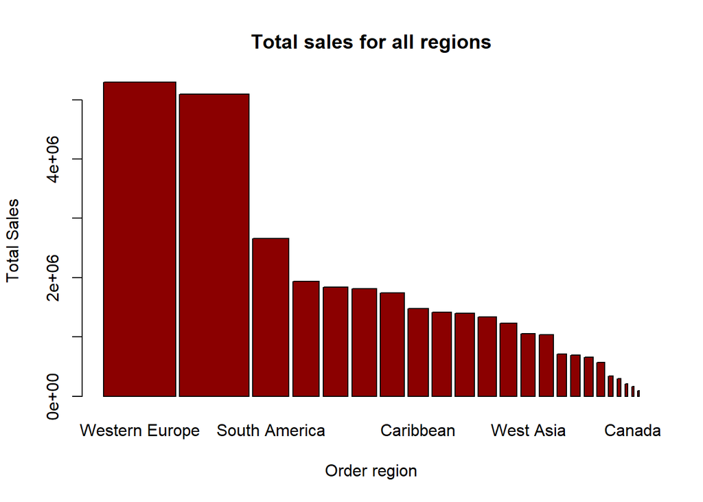

```r
barplot(total_sales$Sales.per.customer,
main = "Total sales for all regions",
xlab = "Order region",
ylab = "Total Sales",
names.arg = total_sales$Order.Region,total_sales$Sales.per.customer,
col = "darkred", horiz = F)
```

### It could be seen from the graph that European market has the greatest number of sales whereas Africa has the least. In these markets western Europe regions and central America recorded highest sales.

```r
total_sales <- v_data%>%
   group_by(Category.Name)
total_sales
```

```
## # A tibble: 180,519 x 41
## # Groups:   Category.Name [50]
##    Type  Days.for.shippi~ Days.for.shipme~ Benefit.per.ord~ Sales.per.custo~
##    <chr>            <int>            <int>            <dbl>            <dbl>
##  1 DEBIT                3                4             91.2             315.
##  2 TRAN~                5                4           -249.              311.
##  3 CASH                 4                4           -248.              310.
##  4 DEBIT                3                4             22.9             305.
##  5 PAYM~                2                4            134.              298.
##  6 TRAN~                6                4             18.6             295.
##  7 DEBIT                2                1             95.2             288.
##  8 TRAN~                2                1             68.4             285.
##  9 CASH                 3                2            134.              279.
## 10 CASH                 2                1            132.              275.
## # ... with 180,509 more rows, and 36 more variables: Delivery.Status <chr>,
## #   Late_delivery_risk <int>, Category.Id <int>, Category.Name <chr>,
## #   Customer.City <chr>, Customer.Country <chr>, Customer.Fname <chr>,
## #   Customer.Id <int>, Customer.Lname <chr>, Customer.Segment <chr>,
## #   Customer.State <chr>, Customer.Zipcode <int>, Department.Id <int>,
## #   Department.Name <chr>, Latitude <dbl>, Longitude <dbl>, Market <chr>,
## #   Order.City <chr>, Order.Country <chr>, order.date..DateOrders. <chr>,
## #   Order.Id <int>, Order.Item.Cardprod.Id <int>, Order.Item.Discount <dbl>,
## #   Order.Item.Discount.Rate <dbl>, Order.Item.Id <int>,
## #   Order.Item.Profit.Ratio <dbl>, Order.Item.Quantity <int>, Sales <dbl>,
## #   Order.Region <chr>, Order.State <chr>, Order.Status <chr>,
## #   Product.Card.Id <int>, Product.Name <chr>, Product.Price <dbl>,
## #   shipping.date..DateOrders. <chr>, Shipping.Mode <chr>
```

```r
total_sales <- total_sales%>%
 summarize(Product.Price = mean(Product.Price))%>%
 arrange(desc(Product.Price))
total_sales
```

```
## # A tibble: 50 x 2
##    Category.Name         Product.Price
##    <chr>                         <dbl>
##  1 "Computers"                   1500
##  2 "Garden"                       533.
##  3 "Strength Training"            495.
##  4 "Crafts"                       461.
##  5 "Cameras "                     452.
##  6 "Basketball"                   404.
##  7 "Fishing"                      400.
##  8 "Children's Clothing"          357.
##  9 "Sporting Goods"               328.
## 10 "Camping & Hiking"             300.
## # ... with 40 more rows
```

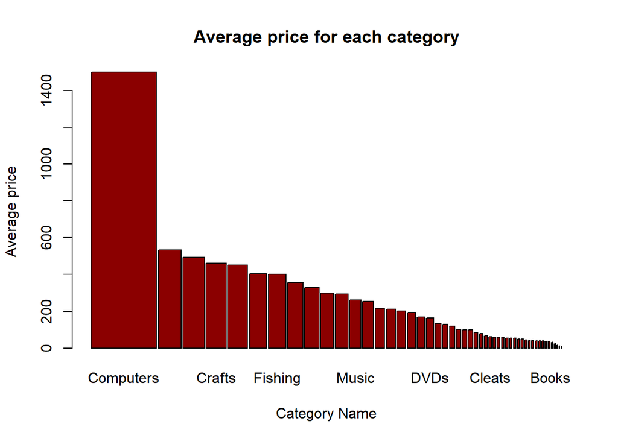

```r
barplot(total_sales$Product.Price,
main = "Average price for each category",
xlab = "Category Name",
ylab = "Average price",
names.arg = total_sales$Category.Name,total_sales$Product.Price,
col = "darkred", horiz = F)
```

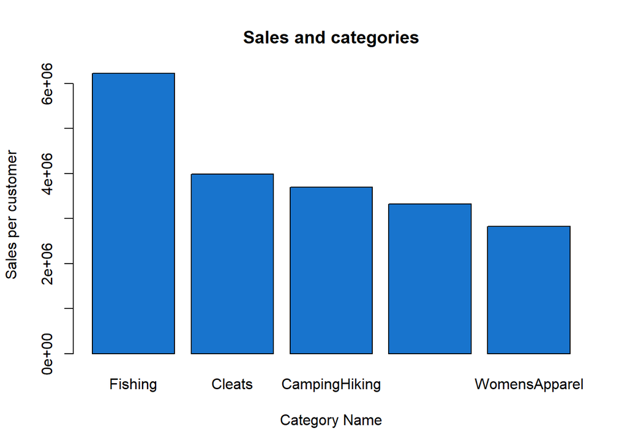

```r
top_5 <- c(Fishing=6226935, Cleats=3982857, CampingHiking=3700784, CardioEquipment=3320251, WomensApparel=2828709)
barplot(top_5,
        col="dodgerblue3",
        main="Sales and categories",
        ylab="Sales per customer",
        xlab= "Category Name")
```

```r
market <- v_data%>%
  group_by(Market)
market
```

```
## # A tibble: 180,519 x 41
## # Groups:   Market [5]
##    Type  Days.for.shippi~ Days.for.shipme~ Benefit.per.ord~ Sales.per.custo~
##    <chr>            <int>            <int>            <dbl>            <dbl>
##  1 DEBIT                3                4             91.2             315.
##  2 TRAN~                5                4           -249.              311.
##  3 CASH                 4                4           -248.              310.
##  4 DEBIT                3                4             22.9             305.
##  5 PAYM~                2                4            134.              298.
##  6 TRAN~                6                4             18.6             295.
##  7 DEBIT                2                1             95.2             288.
##  8 TRAN~                2                1             68.4             285.
##  9 CASH                 3                2            134.              279.
## 10 CASH                 2                1            132.              275.
## # ... with 180,509 more rows, and 36 more variables: Delivery.Status <chr>,
## #   Late_delivery_risk <int>, Category.Id <int>, Category.Name <chr>,
## #   Customer.City <chr>, Customer.Country <chr>, Customer.Fname <chr>,
## #   Customer.Id <int>, Customer.Lname <chr>, Customer.Segment <chr>,
## #   Customer.State <chr>, Customer.Zipcode <int>, Department.Id <int>,
## #   Department.Name <chr>, Latitude <dbl>, Longitude <dbl>, Market <chr>,
## #   Order.City <chr>, Order.Country <chr>, order.date..DateOrders. <chr>,
## #   Order.Id <int>, Order.Item.Cardprod.Id <int>, Order.Item.Discount <dbl>,
## #   Order.Item.Discount.Rate <dbl>, Order.Item.Id <int>,
## #   Order.Item.Profit.Ratio <dbl>, Order.Item.Quantity <int>, Sales <dbl>,
## #   Order.Region <chr>, Order.State <chr>, Order.Status <chr>,
## #   Product.Card.Id <int>, Product.Name <chr>, Product.Price <dbl>,
## #   shipping.date..DateOrders. <chr>, Shipping.Mode <chr>
```

```r
library(dplyr)
market<- market%>%
 summarize(Sales.per.customer = sum(Sales.per.customer))
market
```

```
## # A tibble: 5 x 2
##   Market       Sales.per.customer
##   <chr>                     <dbl>
## 1 Africa                 2061679.
## 2 Europe                 9769198.
## 3 LATAM                  9235762.
## 4 Pacific Asia           7434263.
## 5 USCA                   4553500.
```

```r
market <- market %>% transmute(Market, percent = Sales.per.customer/sum(Sales.per.customer)*100)
market
```

```
## # A tibble: 5 x 2
##   Market       percent
##   <chr>          <dbl>
## 1 Africa          6.24
## 2 Europe         29.6
## 3 LATAM          27.9
## 4 Pacific Asia   22.5
## 5 USCA           13.8
```

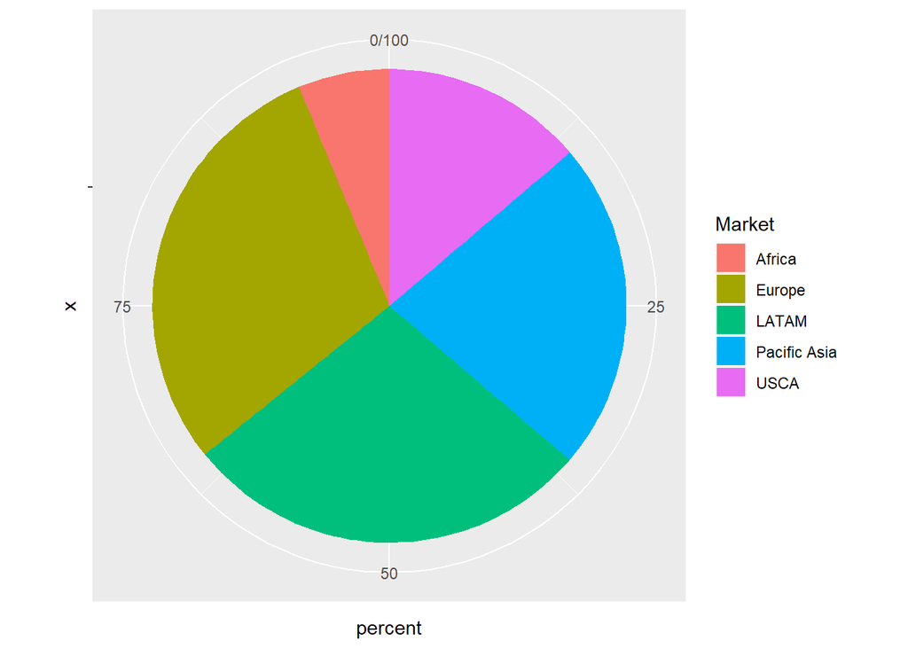

```r
library(ggplot2)
market_share<- ggplot(market, aes(x="", y=percent, fill=Market))+
geom_bar(width = 1, stat = "identity")
pie <- market_share + coord_polar("y", start=0)
pie
```

### Pie chart represents the sales per customer in each market. We can see that Europe and LATAM has majority of sales whereas Africa and USCA has least sales.

```r
customer_segment <- v_data%>%
  group_by(Market,Customer.Segment)

customer_segment <- customer_segment%>%
 summarize(Sales.per.customer = sum(Sales.per.customer))
customer_segment
```

```
## # A tibble: 15 x 3
## # Groups:   Market [5]
##    Market       Customer.Segment Sales.per.customer
##    <chr>        <chr>                         <dbl>
##  1 Africa       Consumer                   1066810.
##  2 Africa       Corporate                   629264.
##  3 Africa       Home Office                 365605.
##  4 Europe       Consumer                   5097709.
##  5 Europe       Corporate                  2968304.
##  6 Europe       Home Office                1703186.
##  7 LATAM        Consumer                   4754728.
##  8 LATAM        Corporate                  2818497.
##  9 LATAM        Home Office                1662537.
## 10 Pacific Asia Consumer                   3853807.
## 11 Pacific Asia Corporate                  2257030.
## 12 Pacific Asia Home Office                1323425.
## 13 USCA         Consumer                   2391223.
## 14 USCA         Corporate                  1357556.
## 15 USCA         Home Office                 804721.
```

```r
customer_segment <- customer_segment %>%
       arrange(desc(Sales.per.customer))
top_10<-top_n(customer_segment,10)
top_10
```

```
## # A tibble: 15 x 3
## # Groups:   Market [5]
##    Market       Customer.Segment Sales.per.customer
##    <chr>        <chr>                         <dbl>
##  1 Europe       Consumer                   5097709.
##  2 LATAM        Consumer                   4754728.
##  3 Pacific Asia Consumer                   3853807.
##  4 Europe       Corporate                  2968304.
##  5 LATAM        Corporate                  2818497.
##  6 USCA         Consumer                   2391223.
##  7 Pacific Asia Corporate                  2257030.
##  8 Europe       Home Office                1703186.
##  9 LATAM        Home Office                1662537.
## 10 USCA         Corporate                  1357556.
## 11 Pacific Asia Home Office                1323425.
## 12 Africa       Consumer                   1066810.
## 13 USCA         Home Office                 804721.
## 14 Africa       Corporate                   629264.
## 15 Africa       Home Office                 365605.
```

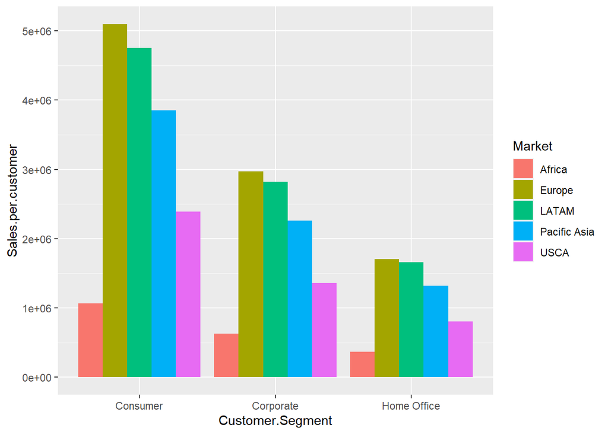

```r
ggplot(top_10, aes(Customer.Segment, Sales.per.customer, fill = Market)) + geom_col(position = "dodge")
```

## Let’s divide data set into data frame

```r
shipment<- select(data,Type,Late_delivery_risk,Days.for.shipping..real.,Days.for.shipment..scheduled.,Benefit.per.order,Sales.per.customer,Latitude,Longitude,Order.Status,Shipping.Mode,Order.Region,Market,Delivery.Status)
head(shipment)
```

```
##       Type Late_delivery_risk Days.for.shipping..real.
## 1    DEBIT                  0                        3
## 2 TRANSFER                  1                        5
## 3     CASH                  0                        4
## 4    DEBIT                  0                        3
## 5  PAYMENT                  0                        2
## 6 TRANSFER                  0                        6
##   Days.for.shipment..scheduled. Benefit.per.order Sales.per.customer Latitude
## 1                             4             91.25             314.64 18.25145
## 2                             4           -249.09             311.36 18.27945
## 3                             4           -247.78             309.72 37.29223
## 4                             4             22.86             304.81 34.12595
## 5                             4            134.21             298.25 18.25377
## 6                             4             18.58             294.98 43.01397
##    Longitude    Order.Status  Shipping.Mode   Order.Region       Market
## 1  -66.03706        COMPLETE Standard Class Southeast Asia Pacific Asia
## 2  -66.03706         PENDING Standard Class     South Asia Pacific Asia
## 3 -121.88128          CLOSED Standard Class     South Asia Pacific Asia
## 4 -118.29102        COMPLETE Standard Class        Oceania Pacific Asia
## 5  -66.03705 PENDING_PAYMENT Standard Class        Oceania Pacific Asia
## 6  -78.87907        CANCELED Standard Class        Oceania Pacific Asia
##     Delivery.Status
## 1  Advance shipping
## 2     Late delivery
## 3  Shipping on time
## 4  Advance shipping
## 5  Advance shipping
## 6 Shipping canceled
```

### Visualize target variables

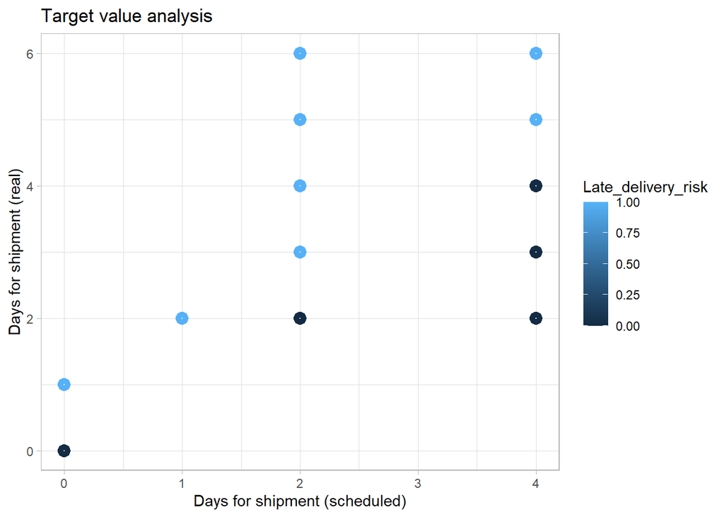

```r
scatter_plot <- ggplot(shipment, aes(Days.for.shipment..scheduled.,Days.for.shipping..real.))
scatter_plot + geom_point(aes(color=Late_delivery_risk),shape = 21,fill="white",size= 0.5,stroke= 3) + theme_light() + labs(x="Days for shipment (scheduled)", y="Days for shipment (real)", title = "Target value analysis")
```

# 4. Model Building

### Data contains 180519 rows, therefore, due to computational expense, we shuffled our data and selected 50,000 rows out of 180519 which are sufficient to run machine learning models.

## To run Linear Regression, all categorical variables in shipment data are converted into numerical values. Following shipment1 vector contains all shipment related data in numerical form.

```r
#install.packages("Metrics")
shipment1<-read.csv("regressormodeldata1.csv")
head(shipment1)
```

```
##   Days.for.shipping..real. Type Late_delivery_risk Benefit.per.order
## 1                        3    1                  0             91.25
## 2                        5    2                  1           -249.09
## 3                        4    3                  0           -247.78
## 4                        3    1                  0             22.86
## 5                        2    4                  0            134.21
## 6                        6    2                  0             18.58
##   Sales.per.customer Latitude  Longitude Order.Status Shipping.Mode
## 1             314.64 18.25145  -66.03706            1             1
## 2             311.36 18.27945  -66.03706            2             1
## 3             309.72 37.29223 -121.88128            3             1
## 4             304.81 34.12595 -118.29102            1             1
## 5             298.25 18.25377  -66.03705            4             1
## 6             294.98 43.01397  -78.87907            5             1
##   Order.Region Delivery.Status Market Days.for.shipment..scheduled.
## 1           16               1      1                             4
## 2           14               2      1                             4
## 3           14               3      1                             4
## 4           12               1      1                             4
## 5           12               1      1                             4
## 6           12               4      1                             4
```

## 4.1 Data Partition

### Shipment data has been divided into training and testing data. Training data contains 80% of the total data and remaining 20% data in used for validation.

```r
library(magrittr)
set.seed(1)
train.index <- sample(c(1:dim(shipment1)[1]), dim(shipment1)[1]*0.8)
train.df <- shipment1[train.index, ]
dim(train.df)
```

```
## [1] 40000    13
```

```r
valid.df <- shipment1[-train.index, ]
dim(valid.df)
```

```
## [1] 10000    13
```

```r
head(valid.df)
```

```
##    Days.for.shipping..real. Type Late_delivery_risk Benefit.per.order
## 6                         6    2                  0             18.58
## 14                        2    1                  1             24.58
## 19                        2    1                  1            102.26
## 23                        4    2                  1             22.37
## 28                        4    4                  0             82.59
## 32                        5    1                  1            113.07
##    Sales.per.customer Latitude  Longitude Order.Status Shipping.Mode
## 6              294.98 43.01397  -78.87907            5             1
## 14             245.81 18.27844  -66.03706            1             2
## 19             314.64 18.23378  -66.03706            1             2
## 23             298.25 38.61177 -121.28287            2             3
## 28             275.31 18.27022  -66.03706            4             1
## 32             245.81 41.86544  -88.10990            1             1
##    Order.Region Delivery.Status Market Days.for.shipment..scheduled.
## 6            12               4      1                             4
## 14           14               2      1                             1
## 19           14               2      1                             1
## 23           12               2      1                             2
## 28            8               3      1                             4
## 32           14               2      1                             4
```

```r
head(train.df)
```

```
##       Days.for.shipping..real. Type Late_delivery_risk Benefit.per.order
## 24388                        4    3                  0            121.99
## 43307                        2    1                  1             31.42
## 4050                         6    1                  1             32.54
## 11571                        6    2                  1             -0.78
## 25173                        2    1                  1             25.48
## 32618                        4    1                  0              4.50
##       Sales.per.customer Latitude  Longitude Order.Status Shipping.Mode
## 24388             248.96 41.82725  -87.77910            3             1
## 43307              92.96 26.09850  -80.27095            1             2
## 4050              287.98 34.85777  -80.84424            1             1
## 11571              39.18 18.22279  -66.37061            6             3
## 25173              90.99 40.09410  -80.59679            1             2
## 32618              44.96 33.18249 -117.37093            1             1
##       Order.Region Delivery.Status Market Days.for.shipment..scheduled.
## 24388           23               3      4                             4
## 43307           20               2      3                             1
## 4050            16               2      1                             4
## 11571           22               2      2                             2
## 25173            7               2      2                             1
## 32618            9               3      4                             4
```

## 4.2 Linear Regression

### The linearity of the model makes the interpretation easy. It is less complicated compared to other machine learning regression models. In this project, the y (dependent) variable is Days for shipping real and rest of the variables are explanatory.

```r
library(Metrics)
# Build the model
model <- lm(Days.for.shipping..real.~Type+Late_delivery_risk+Benefit.per.order+Sales.per.customer+Latitude+Longitude+Order.Status+Shipping.Mode+Order.Region+Delivery.Status+Market+Days.for.shipment..scheduled., data = train.df)
# Summarize the model
summary(model)$coef
```

```
##                                    Estimate   Std. Error       t value
## (Intercept)                   -4.873651e+00 3.270796e-02 -149.00502520
## Type                           1.534761e-02 2.942694e-03    5.21549568
## Late_delivery_risk             2.528437e+00 7.274671e-03  347.56717061
## Benefit.per.order             -3.639337e-06 3.107717e-05   -0.11710644
## Sales.per.customer            -1.146956e-05 2.589502e-05   -0.44292538
## Latitude                      -1.879271e-03 3.948784e-04   -4.75911286
## Longitude                      4.129911e-05 1.695432e-04    0.24359048
## Order.Status                   3.850535e-04 1.659542e-03    0.23202397
## Shipping.Mode                  7.558003e-01 6.334204e-03  119.32049707
## Order.Region                  -3.863319e-04 4.822051e-04   -0.80117753
## Delivery.Status                6.482392e-01 4.941914e-03  131.17168187
## Market                         6.315270e-05 2.141472e-03    0.02949033
## Days.for.shipment..scheduled.  1.500813e+00 4.576442e-03  327.94321719
##                                   Pr(>|t|)
## (Intercept)                   0.000000e+00
## Type                          1.842377e-07
## Late_delivery_risk            0.000000e+00
## Benefit.per.order             9.067763e-01
## Sales.per.customer            6.578221e-01
## Latitude                      1.951244e-06
## Longitude                     8.075493e-01
## Order.Status                  8.165206e-01
## Shipping.Mode                 0.000000e+00
## Order.Region                  4.230336e-01
## Delivery.Status               0.000000e+00
## Market                        9.764737e-01
## Days.for.shipment..scheduled. 0.000000e+00
```

```r
# Make predictions
predictions <- model %>%
  predict(valid.df)
# Model performance
# (a) Prediction error, RMSE
rmse(predictions, valid.df$Days.for.shipping..real.)
```

```
## [1] 0.6602278
```

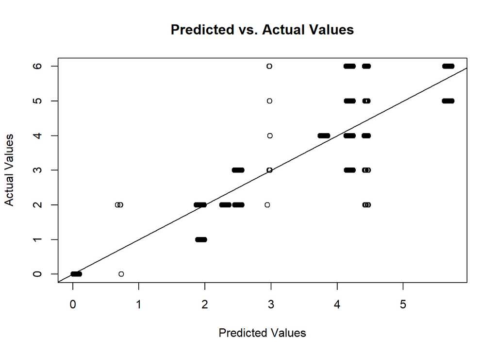

```r
#plot predicted vs. actual values
plot(x=predictions, y=valid.df$Days.for.shipping..real.,
     xlab='Predicted Values',
     ylab='Actual Values',
     main='Predicted vs. Actual Values')
abline(a=0, b=1)
```

```r
values <- data.frame(actual=valid.df$Days.for.shipping..real., predicted=predictions)
#values
round(head(values),2)
```

```
##    actual predicted
## 6       6      4.42
## 14      2      1.93
## 19      2      1.93
## 23      4      4.17
## 28      4      3.85
## 32      5      5.64
```

```r
#dim(values)
#R-square
RSS_LR <- sum((values$predicted - values$actual) ^ 2)  ## residual sum of squares
TSS_LR <- sum((values$actual - mean(values$predicted)) ^ 2)  ## total sum of squares
Rsq_LR <- 1 - RSS_LR/TSS_LR
Rsq_LR
```

```
## [1] 0.8389498
```

```r
#Mean absolute error
MAE_LR<-mae(values$actual,values$predicted)
MAE_LR
```

```
## [1] 0.4884428
```

## 4.3 Random Forest regression

### The randomForest package optionally produces two additional pieces of information: a measure of the importance of the predictor variables, and a measure of the internal structure of the data (the proximity of different data points to one another). It reduces overfitting in decision trees and helps to improve the accuracy.

```r
library(randomForest)
fit <- randomForest(Days.for.shipping..real.~., data=train.df)
# summarize the fit
#summary(fit)
# make predictions
predictions <- predict(fit, valid.df)
#predictions
# summarize accuracy
rmse(predictions, valid.df$Days.for.shipping..real.)
```

```
## [1] 0.545907
```

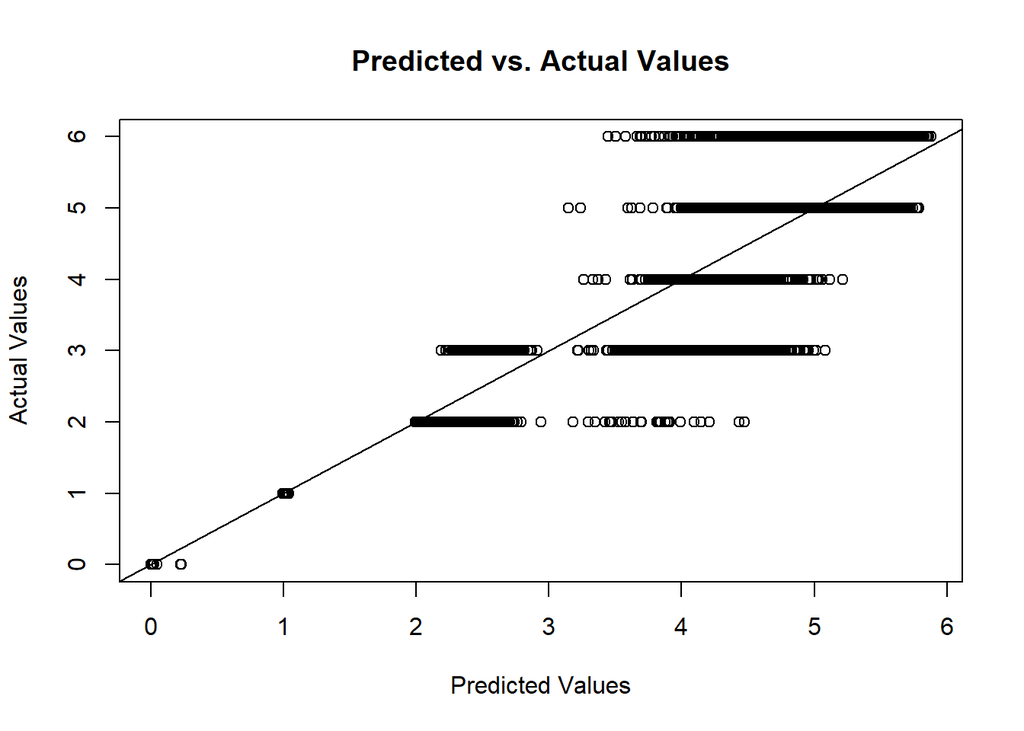

```r
plot(x=predictions, y=valid.df$Days.for.shipping..real.,
     xlab='Predicted Values',
     ylab='Actual Values',
     main='Predicted vs. Actual Values')
abline(a=0, b=1)
```

```r
values <- data.frame(actual=valid.df$Days.for.shipping..real., predicted=predictions)
round(head(values),2)
```

```
##    actual predicted
## 6       6      3.91
## 14      2      2.00
## 19      2      2.00
## 23      4      4.33
## 28      4      3.99
## 32      5      5.27
```

```r
#R-square
RSS_RF <- sum((values$predicted - values$actual) ^ 2)  ## residual sum of squares
TSS_RF <- sum((values$actual - mean(values$predicted)) ^ 2)  ## total sum of squares
Rsq_RF <- 1 - RSS_RF/TSS_RF
Rsq_RF
```

```
## [1] 0.8898899
```

```r
#Mean absolute error
MAE_RF<-mae(values$actual,values$predicted)
MAE_RF
```

```
## [1] 0.358659
```

## 4.4 Gradient Boosting

### Gradient Boost is one of the most popular Machine Learning algorithms in use. Gradient boosting starts by making single leaf instead of a tree. This leaf represents an initial guess of days for shipping real of all the samples. This initial guess in nothing but the average value. Then gradient boost builds a tree based on the errors made by the previous tree. Gradient boost continues to build trees in this fashion until it has made the trees we have asked for.

```r
library('caret')
modfit <- train(Days.for.shipping..real. ~., method = "gbm", data = train.df, verbose = FALSE)
prediction <- predict(modfit, valid.df)

#error <- prediction/valid.df$Days.for.shipping..real. - 1
#summary(error)
#error
rmse(prediction, valid.df$Days.for.shipping..real.)
```

```
## [1] 0.6025861
```

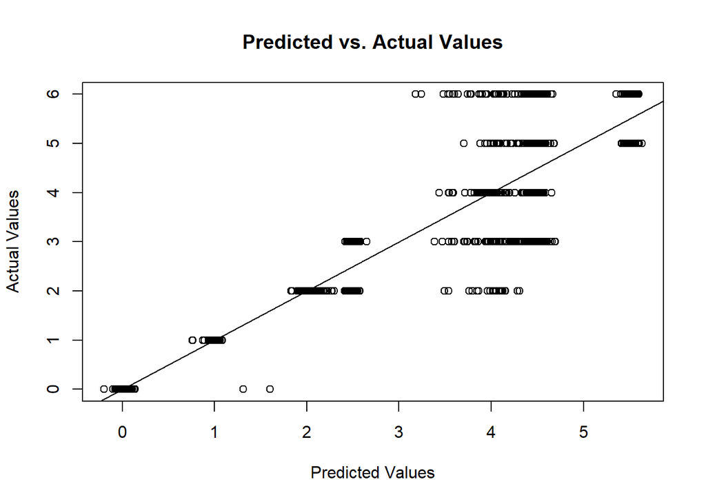

```r
plot(x=prediction, y=valid.df$Days.for.shipping..real.,
     xlab='Predicted Values',
     ylab='Actual Values',
     main='Predicted vs. Actual Values')
abline(a=0, b=1)
```

```r
values <- data.frame(actual=valid.df$Days.for.shipping..real., predicted=prediction)
round(head(values),2)
```

```
##   actual predicted
## 1      6      3.74
## 2      2      1.99
## 3      2      2.01
## 4      4      4.45
## 5      4      3.97
## 6      5      5.49
```

```r
#R-square
RSS_GB <- sum((values$predicted - values$actual) ^ 2)  ## residual sum of squares
TSS_GB <- sum((values$actual - mean(values$predicted)) ^ 2)  ## total sum of squares
Rsq_GB <- 1 - RSS_GB/TSS_GB
Rsq_GB
```

```
## [1] 0.8658379
```

```r
#Mean Absolute error
MAE_GB<-mae(values$actual,values$predicted)
MAE_GB
```

```
## [1] 0.4157674
```

# Results

### R-square and error values of all 3 models are shown below

```r
results <- matrix(c(0.66,0.43,0.48,0.83,0.54,0.29,0.35,0.89,0.60,0.36,0.41,0.86),ncol=4,byrow=T)
colnames(results)<- c("RMSE","MSE","MAE","R-square")
rownames(results) <- c("Linear regression","Random Forest","Gradient boosting")
results <- as.table(results)
results
```

```
##                   RMSE  MSE  MAE R-square
## Linear regression 0.66 0.43 0.48     0.83
## Random Forest     0.54 0.29 0.35     0.89
## Gradient boosting 0.60 0.36 0.41     0.86
```

# Conclusion

### All 3 regression models give a promising result; however, Random forest regression model has a better result as it have low error values. There are various other regression models that can be run on this dataset which might give a better result, but this is the way forward to predict the delivery shipping time.

# References

### [1] https://www.youtube.com/watch?v=3CC4N4z3GJc&t=0s

### [2] https://www.r-graph-gallery.com/piechart-ggplot2.html